# Running Linear mixed-effects models

As a final step, we’ll load multiple files and run a linear mixed effects model

## Packages and commands

Load the following packages: * tidyverse * lmerTest * feather

New commands we’ll be using are: * list.files() * lmer() * map_df()

```r
library(feather)
library(tidyverse)
library(lmerTest)
library(eegUtils)
library(sjPlot)
options(contrasts = c("contr.sum","contr.poly"))
```

## Loading multiple files

In **../data** folder you’ll find a number of *.feather* files. Since these all have the same structure and are the same filetype, we can load them all that once and combine them into a single data frame using *map_df()*. *list.files()* can be used to generate a list of files which meet a particular pattern within a folder. Here we’ll load all the *.feather files.

```r
all_subs <- map_df(list.files('../data/','*.feather', full.names = TRUE),
                   ~read_feather(.x),
                   .id = "Subject")
```

[output not shown]

[output cut: 8 more lines]

[output not shown]

```r
head(all_subs)
```

```
## # A tibble: 6 x 68
##   Subject          condition epoch  time       Fp1       AF7       AF3
##     <chr>              <chr> <dbl> <dbl>     <dbl>     <dbl>     <dbl>
## 1       1 light/no touch/yes     0  -500 19.893007 31.682832 16.552715
## 2       1 light/no touch/yes     0  -492 17.256002 25.285981 18.411364
## 3       1 light/no touch/yes     0  -484 14.513708 20.819642 16.298042
## 4       1 light/no touch/yes     0  -477  9.991514 16.306424 12.541739
## 5       1 light/no touch/yes     0  -469  4.414315 10.309794  7.767697
## 6       1 light/no touch/yes     0  -461  2.759263  9.942333  1.718084
## # ... with 61 more variables: F1 <dbl>, F3 <dbl>, F5 <dbl>, F7 <dbl>,
## #   FT7 <dbl>, FC5 <dbl>, FC3 <dbl>, FC1 <dbl>, C1 <dbl>, C3 <dbl>,
## #   C5 <dbl>, T7 <dbl>, TP7 <dbl>, CP5 <dbl>, CP3 <dbl>, CP1 <dbl>,
## #   P1 <dbl>, P3 <dbl>, P5 <dbl>, P7 <dbl>, P9 <dbl>, PO7 <dbl>,
## #   PO3 <dbl>, O1 <dbl>, Iz <dbl>, Oz <dbl>, POz <dbl>, Pz <dbl>,
## #   CPz <dbl>, Fpz <dbl>, Fp2 <dbl>, AF8 <dbl>, AF4 <dbl>, AFz <dbl>,
## #   Fz <dbl>, F2 <dbl>, F4 <dbl>, F6 <dbl>, F8 <dbl>, FT8 <dbl>,
## #   FC6 <dbl>, FC4 <dbl>, FC2 <dbl>, FCz <dbl>, Cz <dbl>, C2 <dbl>,
## #   C4 <dbl>, C6 <dbl>, T8 <dbl>, TP8 <dbl>, CP6 <dbl>, CP4 <dbl>,
## #   CP2 <dbl>, P2 <dbl>, P4 <dbl>, P6 <dbl>, P8 <dbl>, P10 <dbl>,
## #   PO8 <dbl>, PO4 <dbl>, O2 <dbl>
```

Let’s make the data a little more manageable and convert it to long format. Use *filter()* to choose data from -100 to 400 ms; *separate()* to split up the condition column; and *gather()* to convert the data to long format fully.

```r
all_subs <- all_subs %>%
  filter(time >= -100 & time <= 400) %>%
  separate(condition, into = c("light", "touch", "reported"), sep = "/") %>%
  gather(electrode, amplitude, Fp1:O2)

head(all_subs)
```

```
## # A tibble: 6 x 8
##   Subject light    touch reported epoch  time electrode amplitude
##     <chr> <chr>    <chr>    <chr> <dbl> <dbl>     <chr>     <dbl>
## 1       1 light no touch      yes     0   -94       Fp1  21.17125
## 2       1 light no touch      yes     0   -86       Fp1  13.40901
## 3       1 light no touch      yes     0   -78       Fp1  11.74697
## 4       1 light no touch      yes     0   -70       Fp1  13.01529
## 5       1 light no touch      yes     0   -62       Fp1  12.35089
## 6       1 light no touch      yes     0   -55       Fp1  13.76353
```

## Summarise and plot grand mean ERPs

It is extremely simple to produce grand means; we’ll do this in a single chain of piped commands, since we do not want to keep teh grand averaged data - for LMEs, we need single trials.

```
## No summary function supplied, defaulting to `mean_se()
```

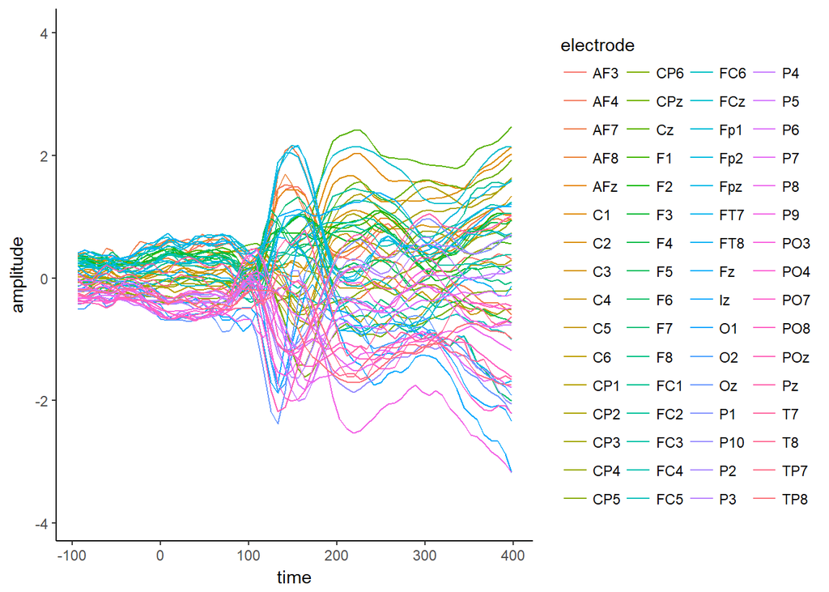

```r
all_subs %>%
  group_by(Subject, electrode, time) %>%
  summarise(amplitude = mean(amplitude)) %>%
  ggplot(aes(x = time, y = amplitude, colour = electrode)) +
  stat_summary(geom = "line") +
  theme_classic()
```

## Baseline correction

The data here needs to be baseline corrected. We’ll calculate the baseline for each subject and electrode and use *left_join()* to add it to the original data frame.

```r
all_subs <- left_join(all_subs, all_subs %>%
  filter(time >= -100 & time <= 0) %>%
  group_by(Subject, electrode) %>%
  summarise(baseline = mean(amplitude)),
  by = c("Subject","electrode"))

head(all_subs)
```

```
## # A tibble: 6 x 9
##   Subject light    touch reported epoch  time electrode amplitude
##     <chr> <chr>    <chr>    <chr> <dbl> <dbl>     <chr>     <dbl>
## 1       1 light no touch      yes     0   -94       Fp1  21.17125
## 2       1 light no touch      yes     0   -86       Fp1  13.40901
## 3       1 light no touch      yes     0   -78       Fp1  11.74697
## 4       1 light no touch      yes     0   -70       Fp1  13.01529
## 5       1 light no touch      yes     0   -62       Fp1  12.35089
## 6       1 light no touch      yes     0   -55       Fp1  13.76353
## # ... with 1 more variables: baseline <dbl>
```

```r
all_subs$amplitude <- all_subs$amplitude - all_subs$baseline
```

Now we’ll plot the basline corrected data.

```
## No summary function supplied, defaulting to `mean_se()
```

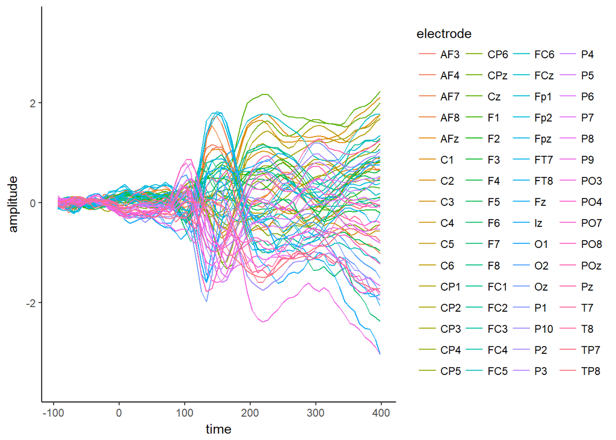

```r
all_subs %>%
  group_by(Subject, electrode, time) %>%
  summarise(amplitude = mean(amplitude)) %>%
  ggplot(aes(x = time, y = amplitude, colour = electrode)) +
  stat_summary(geom = "line") +
  theme_classic()
```

## Select data for LME

LMEs can take quite a while to run (amongst other things…). For our workshop purposes, let’s choose a specific time window to average over and a single electrode of interest. We’ll pick 140 to 170 ms.

```r
mini_data <- all_subs %>%
  filter(time >= 140 & time <= 170) %>%
  group_by(Subject,touch,light,epoch, electrode) %>%
  summarise(amplitude = mean(amplitude)) %>%
  ungroup()
```

Let’s use *topoplot()* from **eegUtils**.

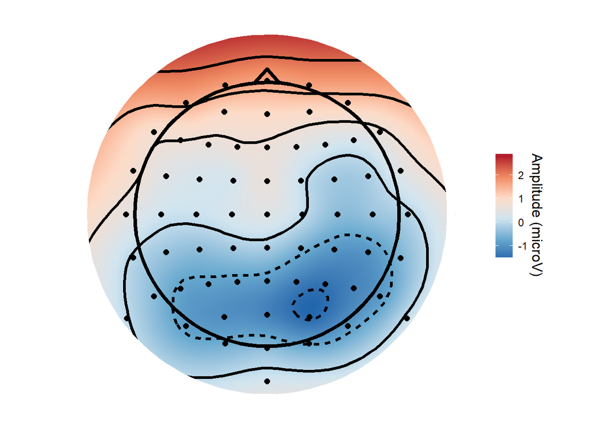

```r
mini_data %>%
  group_by(Subject,electrode) %>%
  summarise(amplitude = mean(amplitude)) %>%
  topoplot()
```

Looks like we have something going on at occipital electrodes. Let’s focus in on one electrode, PO4.

## Run an LME

```r
lme_out <- mini_data %>%
  filter(electrode == "PO4") %>%
  group_by(Subject, light, touch, epoch) %>%
  summarise(amplitude = mean(amplitude)) %>%
  ungroup() %>%
  lmer(amplitude ~ touch*light + (1 + touch*light|Subject), data = .)
```

We can use summary to have a look at the results.

```r
summary(lme_out)
```

```
## summary from lme4 is returned
## some computational error has occurred in lmerTest
```

```
## Linear mixed model fit by REML ['lmerMod']
## Formula: amplitude ~ touch * light + (1 + touch * light | Subject)
##    Data: .
##
## REML criterion at convergence: 49023.6
##
## Scaled residuals:
##     Min      1Q  Median      3Q     Max
## -6.1801 -0.5867 -0.0095  0.5842  5.2364
##
## Random effects:
##  Groups   Name          Variance Std.Dev. Corr
##  Subject  (Intercept)    3.68161 1.9188
##           touch1         0.06276 0.2505    0.34
##           light1         3.79764 1.9488    0.94  0.58
##           touch1:light1  0.04169 0.2042   -0.62 -0.08 -0.40
##  Residual               94.42968 9.7175
## Number of obs: 6628, groups:  Subject, 16
##
## Fixed effects:
##               Estimate Std. Error t value
## (Intercept)   -1.64947    0.49446  -3.336
## touch1        -0.14875    0.13500  -1.102
## light1        -1.52513    0.50173  -3.040
## touch1:light1 -0.01195    0.13002  -0.092
##
## Correlation of Fixed Effects:
##             (Intr) touch1 light1
## touch1       0.151
## light1       0.891  0.261
## toch1:lght1 -0.235  0.025 -0.154
```

## Plot fixed and random effects

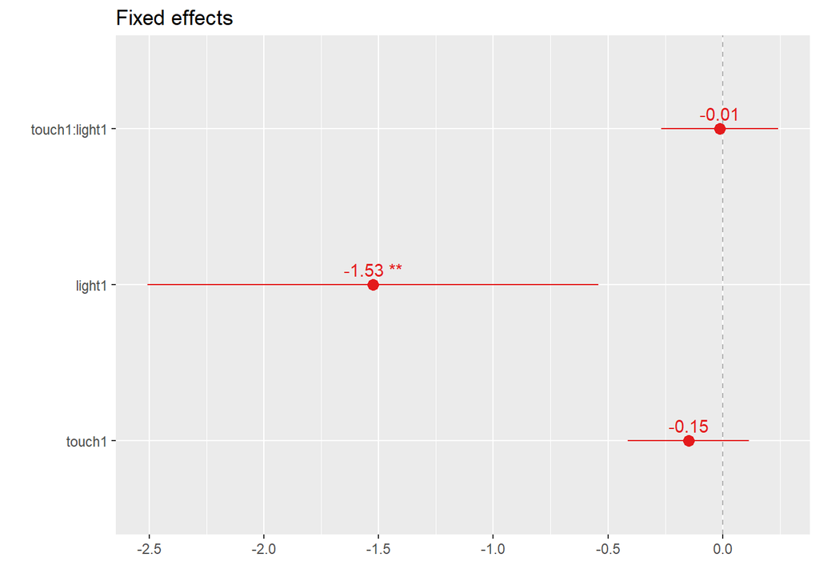

```r
sjp.lmer(lme_out, type = "fe", p.kr = FALSE)
```

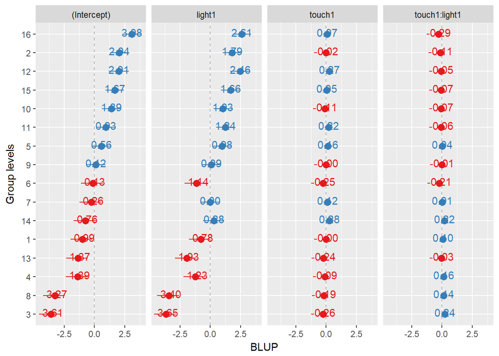

```r
sjp.lmer(lme_out, type = "re", sort.est = "(Intercept)")
```

We can try to run a full LME on every timepoint. Let’s see what happens.

```r
mo_problems <- all_subs %>%
  filter(electrode == "PO4") %>%
  ungroup() %>%
  nest(-time) %>%
  mutate(lme_out = map(data, ~lmer(amplitude~touch*light + (1 + touch*light |Subject), data = .)))
```